# AOA analysis

### ANOVA: choosing a model

An analysis of the dataset structure is needed to find the right statistical model. The data was generated in a randomized complete block design (RCBD).

##### Model parameters

###### Fixed effects

- Fertilizer (fert) (Binary variable (yes/no))
- Fungicide and growth (fung) (Binary variable (yes/no))

###### Random effects

- Time
- Block
- (Row)
- (Could possibly include rainfall 3-7 days before sampling)

#### Mixed effect model

The model needs to account for the above listed fixed and random effects. The regular lm() function of R stats package will fit all variables as fixed effects if they are integrated into the forumlae. Therefore we need the package nlme which can account for random effects. Because we are using only two timepoints I will stick to a linear model. Generally, I’d consider a non-linear model if all timepoints would be in the analysis. We are investigating gene copy numbers which are directly correlated and have a causal relation ship with number of bacteria. Bacteria growth is better estimated with a logistic regression.

I’ll do a stepwise modelling approach without the mathematic forumlae (will be done in the thesis tho).

##### All main effects + Interaction (Full model)

```r
# Fitting a linear mixed effect model to our genecopynumber dataset
  # Treatment variables (fert|fung) are treated as fixed effects
  # Time and Block are random effect variables (can't be replicated)
  # We use the package nlme to effectively input random effect variables for our model
  # Interaction of fert*fung must be tested, because we have two factorial experiment
  # It is also possible to just type in fert*fung as predictor variable, the package will fit also the main effects
  # If more timepoints of this are used, a non-linear model would be better because bacteria growth is not linear

  fit.all <- lme(qty_ng ~ fert+fung+fert*fung,
                  random = list(~1|block, ~1|time),
                  data=genecopy.work)
  summary(fit.all)
```

```
## Linear mixed-effects model fit by REML
##   Data: genecopy.work
##        AIC      BIC    logLik
##   739.6096 750.6942 -362.8048
##
## Random effects:
##  Formula: ~1 | block
##         (Intercept)
## StdDev:   0.4760895
##
##  Formula: ~1 | time %in% block
##         (Intercept) Residual
## StdDev:    3456.146 4326.919
##
## Fixed effects:  qty_ng ~ fert + fung + fert * fung
##                     Value Std.Error DF   t-value p-value
## (Intercept)     16761.150  1751.205 27  9.571212  0.0000
## fertyes             7.647  1935.057 27  0.003952  0.9969
## fungyes         -2798.173  1935.057 27 -1.446042  0.1597
## fertyes:fungyes -2573.775  2736.584 27 -0.940506  0.3553
##  Correlation:
##                 (Intr) fertys fungys
## fertyes         -0.552
## fungyes         -0.552  0.500
## fertyes:fungyes  0.391 -0.707 -0.707
##
## Standardized Within-Group Residuals:
##         Min          Q1         Med          Q3         Max
## -2.20820726 -0.56985434 -0.06685674  0.68134468  1.86476479
##
## Number of Observations: 40
## Number of Groups:
##           block time %in% block
##               5              10
```

The interaction term is not significant, so I’m droping it from the model, leaving only the main effects in.

##### Both main effects (Reduced model)

```r
  fit.nointeraction <- lme(qty_ng ~ fert+fung,
                  random = list(~1|block, ~1|time),
                  data=genecopy.work)
  summary(fit.nointeraction)
```

```
## Linear mixed-effects model fit by REML
##   Data: genecopy.work
##        AIC      BIC    logLik
##   756.1607 765.8262 -372.0804
##
## Random effects:
##  Formula: ~1 | block
##         (Intercept)
## StdDev:   0.4637623
##
##  Formula: ~1 | time %in% block
##         (Intercept) Residual
## StdDev:    3458.937  4317.99
##
## Fixed effects:  qty_ng ~ fert + fung
##                 Value Std.Error DF   t-value p-value
## (Intercept) 17404.593  1610.839 28 10.804677  0.0000
## fertyes     -1279.240  1365.468 28 -0.936851  0.3568
## fungyes     -4085.061  1365.468 28 -2.991692  0.0057
##  Correlation:
##         (Intr) fertys
## fertyes -0.424
## fungyes -0.424  0.000
##
## Standardized Within-Group Residuals:
##         Min          Q1         Med          Q3         Max
## -2.06284193 -0.65555489  0.01054032  0.53446981  2.01585393
##
## Number of Observations: 40
## Number of Groups:
##           block time %in% block
##               5              10
```

Fungicide is highly sig. while fertilizer is not sig. Dropping fert from the model.

##### Only Fung as main effect

```r
  fit.nofert <- lme(qty_ng ~ fung,
                  random = list(~1|block,~1|time),
                  data=genecopy.work)
  summary(fit.nofert)
```

```
## Linear mixed-effects model fit by REML
##   Data: genecopy.work
##        AIC      BIC    logLik
##   771.3145 779.5025 -380.6573
##
## Random effects:
##  Formula: ~1 | block
##         (Intercept)
## StdDev:   0.4410303
##
##  Formula: ~1 | time %in% block
##         (Intercept) Residual
## StdDev:    3461.777 4308.874
##
## Fixed effects:  qty_ng ~ fung
##                 Value Std.Error DF   t-value p-value
## (Intercept) 16764.973  1458.324 29 11.496052  0.0000
## fungyes     -4085.061  1362.586 29 -2.998021  0.0055
##  Correlation:
##         (Intr)
## fungyes -0.467
##
## Standardized Within-Group Residuals:
##         Min          Q1         Med          Q3         Max
## -2.21471208 -0.52930620 -0.01005845  0.54225054  1.86985698
##
## Number of Observations: 40
## Number of Groups:
##           block time %in% block
##               5              10
```

## Soil

### Checking the datas balance

| fert | fung | time | variable | n | mean | sd |
| --- | --- | --- | --- | --- | --- | --- |
| no | no | t2 | qty_ng | 5 | 18744.43 | 2493.176 |
| no | no | t3 | qty_ng | 5 | 31818.17 | 5844.211 |
| no | yes | t2 | qty_ng | 5 | 21809.03 | 12473.598 |
| no | yes | t3 | qty_ng | 5 | 26743.55 | 3831.755 |
| yes | no | t2 | qty_ng | 5 | 19641.73 | 1964.986 |
| yes | no | t3 | qty_ng | 5 | 23914.54 | 3150.514 |
| yes | yes | t2 | qty_ng | 5 | 15661.08 | 1280.291 |
| yes | yes | t3 | qty_ng | 5 | 18279.19 | 4625.787 |

We have a balanced dataset (n is the same for each group). Moving on to a boxplot to visually inspect groups and look for outliers.

### Boxplot to inspect data visually

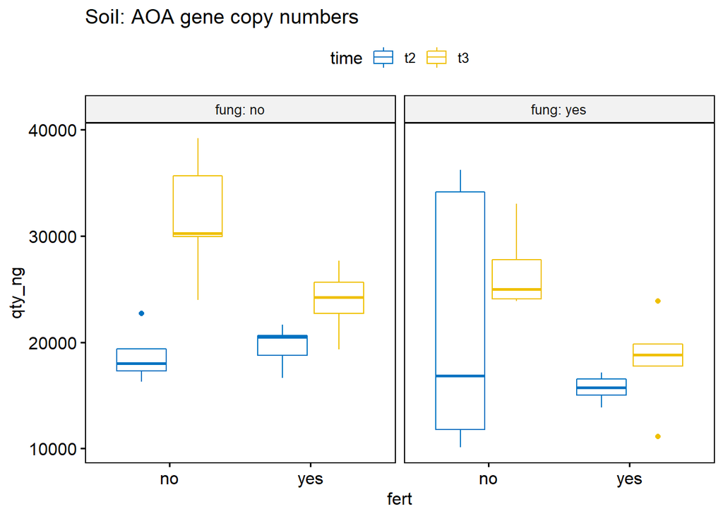

We have one outlier in ‘[fert:no|fung:no|time:t2]’, and two in ‘[fert:yes|fung:yes|time:t3]’. The boxplot of [fert:no|fung:yes|time:t2] is very broad, which the SD of the previous table already predicted. Lets check the outliers. ### Identifying the outliers.

```r
  outlier <-  genecopy.work %>%
    group_by(fert,fung, time) %>%
    identify_outliers(qty_ng)
  outlier
```

| fert | fung | time | id | qty_ng | block | row | is.outlier | is.extreme |
| --- | --- | --- | --- | --- | --- | --- | --- | --- |
| no | no | t2 | 259 | 22735.31 | e | 3 | TRUE | FALSE |
| yes | yes | t3 | 349 | 23872.26 | d | 3 | TRUE | FALSE |
| yes | yes | t3 | 372 | 11116.88 | f | 4 | TRUE | TRUE |

One outlier in ‘[fert:yes|fung:yes|time:t3]’ is extreme.

> Values above Q3 + 1.5xIQR or below Q1 - 1.5xIQR are considered as outliers. Values above Q3 + 3xIQR or below Q1 - 3xIQR are considered as extreme points (or extreme outliers).

Lets check the groups datatable:

###### Datatable from group [fert:yes|fung:yes|time:t3]

| id | qty_ng | fert | fung | block | row | time |
| --- | --- | --- | --- | --- | --- | --- |
| 312 | 17738.83 | yes | yes | b | 1 | t3 |
| 330 | 19830.58 | yes | yes | c | 2 | t3 |
| 349 | 23872.26 | yes | yes | d | 3 | t3 |
| 365 | 18837.42 | yes | yes | e | 4 | t3 |
| 372 | 11116.88 | yes | yes | f | 4 | t3 |

372 is relatively low compared to the others, but subjectively is within range. So I’ll keep it for the time being

### Normality and heteroskedasticity

| fert | fung | time | variable | statistic | p |
| --- | --- | --- | --- | --- | --- |
| no | no | t2 | qty_ng | 0.9154781 | 0.5011993 |
| no | no | t3 | qty_ng | 0.9676581 | 0.8600209 |
| no | yes | t2 | qty_ng | 0.8325293 | 0.1453071 |
| no | yes | t3 | qty_ng | 0.8249467 | 0.1274157 |
| yes | no | t2 | qty_ng | 0.9220684 | 0.5433703 |
| yes | no | t3 | qty_ng | 0.9857464 | 0.9627956 |
| yes | yes | t2 | qty_ng | 0.9793865 | 0.9313097 |
| yes | yes | t3 | qty_ng | 0.9426978 | 0.6850694 |

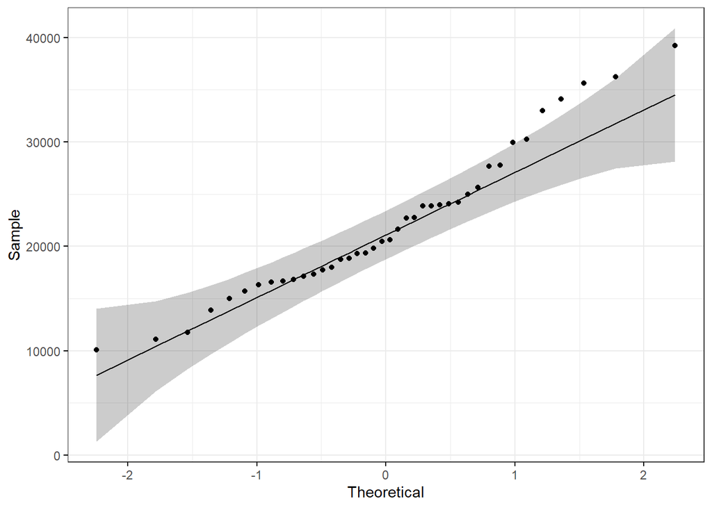

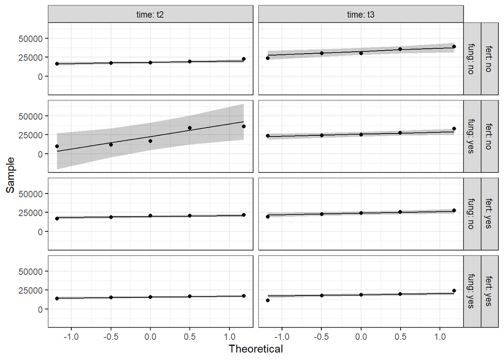

All groups pass the normality test. QQplots look reasonably heteroskedastic. Has a bit of a tail, more extreme values.

### ANOVA: Choosing a model

An analysis of the dataset structure is needed to find the right statistical model. The data was generated in a randomized complete block design (RCBD).

##### Model parameters

###### Fixed effects

- Fertilizer (fert) (Binary variable (yes/no))
- Fungicide and growth (fung) (Binary variable (yes/no))

###### Random effects

- Time
- Block
- (Row)
- (Could possibly include rainfall 3-7 days before sampling)

#### Mixed effect model

The model needs to account for the above listed fixed and random effects. The regular lm() function of R stats package will fit all variables as fixed effects if they are integrated into the forumlae. Therefore we need the package nlme which can account for random effects. Because we are using only two timepoints I will stick to a linear model. Generally, I’d consider a non-linear model if all timepoints would be in the analysis. We are investigating gene copy numbers which are directly correlated and have a causal relation ship with number of bacteria. Bacteria growth is better estimated with a logistic regression.

I’ll do a stepwise modelling approach without the mathematic forumlae (will be done in the thesis tho).

##### All main effects + Interaction (Full model)

```
## Linear mixed-effects model fit by REML
##   Data: genecopy.work
##        AIC      BIC   logLik
##   756.4659 769.1341 -370.233
##
## Random effects:
##  Formula: ~1 | block
##         (Intercept)
## StdDev:     1.01348
##
##  Formula: ~1 | time %in% block
##         (Intercept)
## StdDev:    3216.746
##
##  Formula: ~1 | row %in% time %in% block
##         (Intercept) Residual
## StdDev:    1697.545 5432.312
##
## Fixed effects:  qty_ng ~ fert + fung + fert * fung
##                     Value Std.Error DF   t-value p-value
## (Intercept)     25345.965  2064.630 18 12.276276  0.0000
## fertyes         -3697.046  2494.575 18 -1.482035  0.1556
## fungyes         -1204.367  2483.730 18 -0.484902  0.6336
## fertyes:fungyes -3383.218  3481.467 18 -0.971779  0.3440
##  Correlation:
##                 (Intr) fertys fungys
## fertyes         -0.604
## fungyes         -0.602  0.511
## fertyes:fungyes  0.426 -0.707 -0.710
##
## Standardized Within-Group Residuals:
##         Min          Q1         Med          Q3         Max
## -1.80826516 -0.55234045 -0.02173024  0.49366901  2.12360735
##
## Number of Observations: 40
## Number of Groups:
##                    block          time %in% block row %in% time %in% block
##                        5                       10                       19
```

Interaction is not sig. Dropping it from the model ##### Reduced model (both main effects)

```
## Linear mixed-effects model fit by REML
##   Data: genecopy.work
##        AIC     BIC    logLik
##   771.8554 781.521 -379.9277
##
## Random effects:
##  Formula: ~1 | block
##         (Intercept)
## StdDev:   0.9658047
##
##  Formula: ~1 | time %in% block
##         (Intercept) Residual
## StdDev:    3473.564 5557.132
##
## Fixed effects:  qty_ng ~ fert + fung
##                 Value Std.Error DF   t-value p-value
## (Intercept) 26232.044  1876.884 28 13.976381  0.0000
## fertyes     -5404.656  1757.319 28 -3.075511  0.0047
## fungyes     -2906.503  1757.319 28 -1.653941  0.1093
##  Correlation:
##         (Intr) fertys
## fertyes -0.468
## fungyes -0.468  0.000
##
## Standardized Within-Group Residuals:
##          Min           Q1          Med           Q3          Max
## -1.655895037 -0.672092061  0.005685954  0.459898169  2.292711985
##
## Number of Observations: 40
## Number of Groups:
##           block time %in% block
##               5              10
```

##### Reduced model 2 (only fert)

```
## Linear mixed-effects model fit by REML
##   Data: genecopy.work
##       AIC      BIC   logLik
##   789.322 797.5099 -389.661
##
## Random effects:
##  Formula: ~1 | block
##         (Intercept)
## StdDev:    1.154986
##
##  Formula: ~1 | time %in% block
##         (Intercept) Residual
## StdDev:    3406.407 5721.001
##
## Fixed effects:  qty_ng ~ fert
##                 Value Std.Error DF   t-value p-value
## (Intercept) 24778.793  1672.380 29 14.816488  0.0000
## fertyes     -5404.656  1809.139 29 -2.987418  0.0057
##  Correlation:
##         (Intr)
## fertyes -0.541
##
## Standardized Within-Group Residuals:
##         Min          Q1         Med          Q3         Max
## -1.88942228 -0.57717424 -0.08396998  0.65684491  1.97410054
##
## Number of Observations: 40
## Number of Groups:
##           block time %in% block
##               5              10
```